# 50 LYS SIDE_0_0.1_10_Density

## Sample=6vcx-a:47:cd-a:47:cg-a:47:ce

| pdb_code | central atom | ca density | parallel atom | pa density | planar atom | pl density |
| --- | --- | --- | --- | --- | --- | --- |
| 6vcx | [3.97, 23.98, 49.01] | 105.4716 | [3.62, 23.45, 47.62] | 109.9489 | [3.65, 25.44, 49.26] | 121.2416 |

## Slices along x,y and z

Sliced x-wise

Sliced y-wise

Sliced z-wise

50/101

50/101

50/101

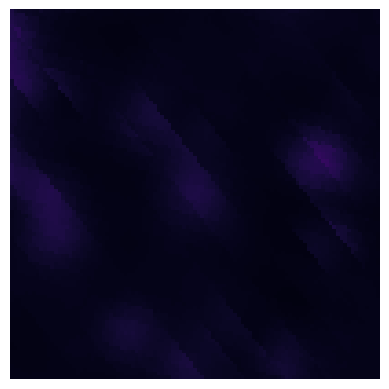

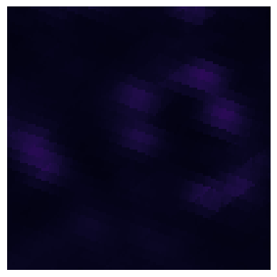

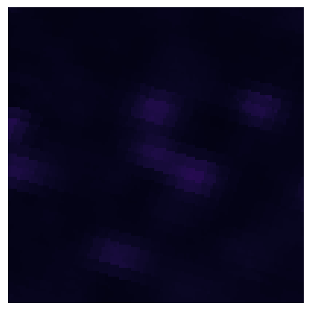

## Sample=6vcx-a:390:cd-a:390:cg-a:390:ce

| pdb_code | central atom | ca density | parallel atom | pa density | planar atom | pl density |
| --- | --- | --- | --- | --- | --- | --- |
| 6vcx | [13.98, -3.32, -2.86] | 77.2976 | [13.35, -1.93, -2.72] | 88.1449 | [14.54, -3.88, -1.57] | 53.05 |

## Slices along x,y and z

Sliced x-wise

Sliced y-wise

Sliced z-wise

50/101

50/101

50/101

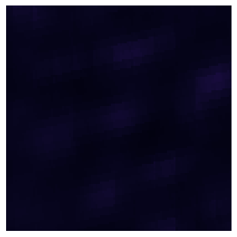

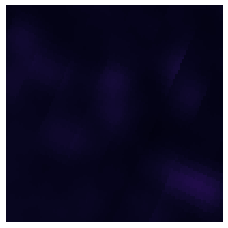

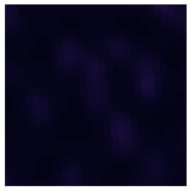

## Sample=3c6z-a:129:cd-a:129:cg-a:129:ce

| pdb_code | central atom | ca density | parallel atom | pa density | planar atom | pl density |
| --- | --- | --- | --- | --- | --- | --- |
| 3c6z | [18.21, 63.17, 20.67] | 186.422 | [16.86, 63.36, 21.33] | 180.3754 | [19.3, 62.97, 21.7] | 178.1775 |

## Slices along x,y and z

Sliced x-wise

Sliced y-wise

Sliced z-wise

50/101

50/101

50/101

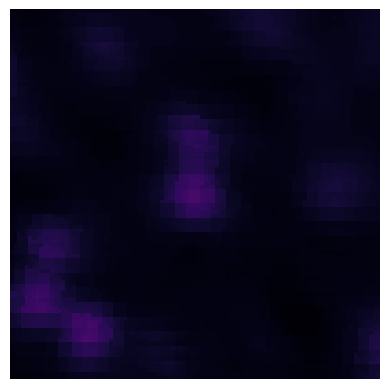

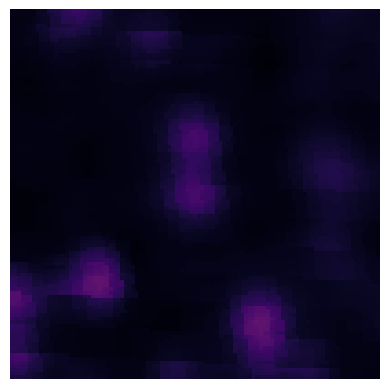

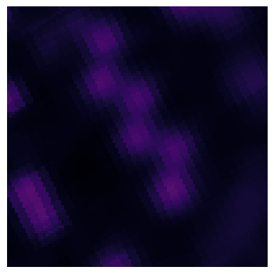

## Sample=1i1w-a:183:cd-a:183:cg-a:183:ce

| pdb_code | central atom | ca density | parallel atom | pa density | planar atom | pl density |
| --- | --- | --- | --- | --- | --- | --- |
| 1i1w | [4.1, 12.91, 13.46] | 112.0873 | [2.75, 12.79, 12.74] | 129.8927 | [5.24, 12.46, 12.58] | 123.9121 |

## Slices along x,y and z

Sliced x-wise

Sliced y-wise

Sliced z-wise

50/101

50/101

50/101

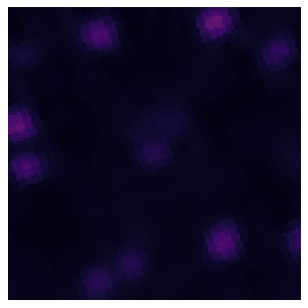

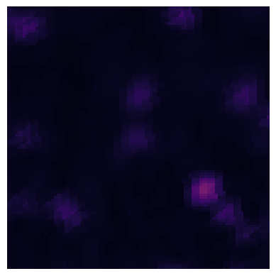

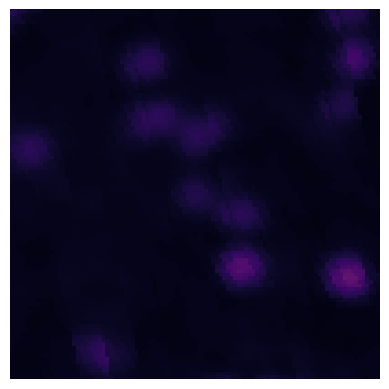

## Sample=6hhm-a:325:cd-a:325:cg-a:325:ce

| pdb_code | central atom | ca density | parallel atom | pa density | planar atom | pl density |
| --- | --- | --- | --- | --- | --- | --- |
| 6hhm | [-10.22, 9.89, -24.3] | 193.9941 | [-9.54, 10.64, -23.15] | 177.348 | [-9.3, 8.88, -24.96] | 181.1012 |

## Slices along x,y and z

Sliced x-wise

Sliced y-wise

Sliced z-wise

50/101

50/101

50/101

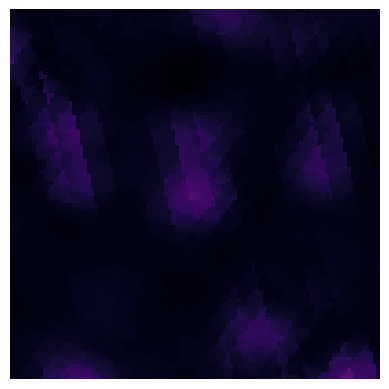

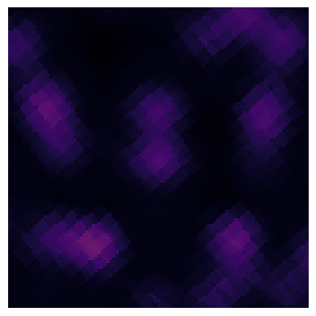

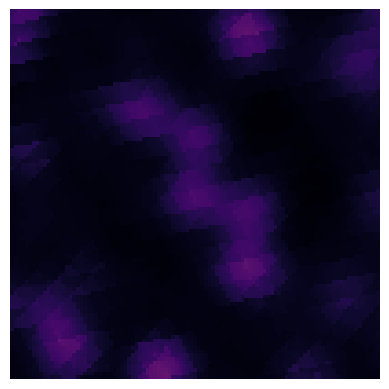

## Sample=2cnq-a:111:cd-a:111:cg-a:111:ce

| pdb_code | central atom | ca density | parallel atom | pa density | planar atom | pl density |
| --- | --- | --- | --- | --- | --- | --- |
| 2cnq | [-3.83, 30.15, 29.7] | 94.9701 | [-4.55, 28.78, 29.81] | 111.0221 | [-4.68, 31.46, 29.93] | 88.2065 |

## Slices along x,y and z

Sliced x-wise

Sliced y-wise

Sliced z-wise

50/101

50/101

50/101

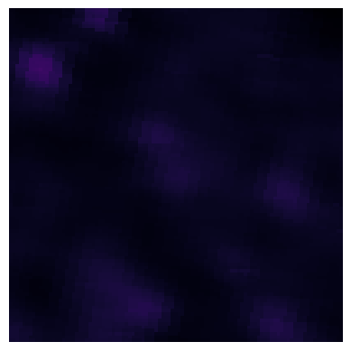

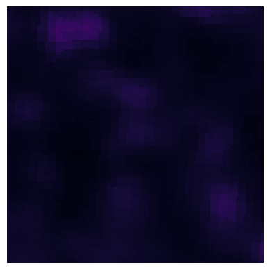

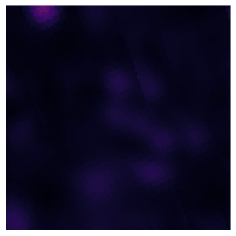

## Sample=1i4u-a:2:cd-a:2:cg-a:2:ce

| pdb_code | central atom | ca density | parallel atom | pa density | planar atom | pl density |
| --- | --- | --- | --- | --- | --- | --- |
| 1i4u | [1.28, -5.05, 21.49] | 66.876 | [1.73, -6.27, 20.72] | 74.9097 | [-0.2, -4.77, 21.62] | 63.6098 |

## Slices along x,y and z

Sliced x-wise

Sliced y-wise

Sliced z-wise

50/101

50/101

50/101

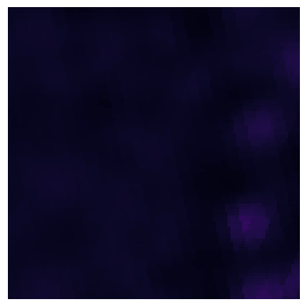

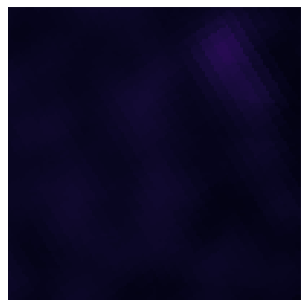

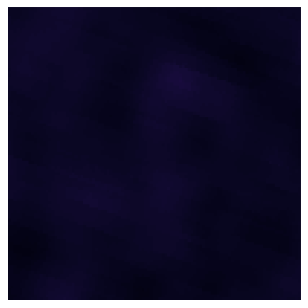

## Sample=6j03-a:209:cd-a:209:cg-a:209:ce

| pdb_code | central atom | ca density | parallel atom | pa density | planar atom | pl density |
| --- | --- | --- | --- | --- | --- | --- |
| 6j03 | [1.07, 61.79, 162.36] | 60.1987 | [0.73, 63.21, 162.81] | 81.892 | [1.86, 61.72, 161.07] | 66.2073 |

## Slices along x,y and z

Sliced x-wise

Sliced y-wise

Sliced z-wise

50/101

50/101

50/101

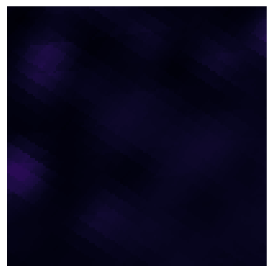

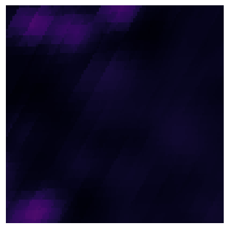

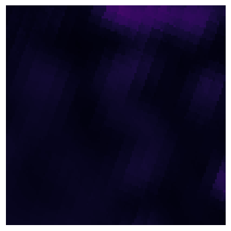

## Sample=3tq2-a:6:cd-a:6:cg-a:6:ce

| pdb_code | central atom | ca density | parallel atom | pa density | planar atom | pl density |
| --- | --- | --- | --- | --- | --- | --- |
| 3tq2 | [-5.59, 6.89, 37.08] | 64.4478 | [-4.46, 6.72, 38.09] | 76.772 | [-6.72, 5.91, 37.36] | 66.928 |

## Slices along x,y and z

Sliced x-wise

Sliced y-wise

Sliced z-wise

50/101

50/101

50/101

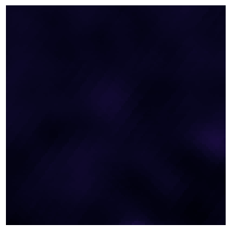

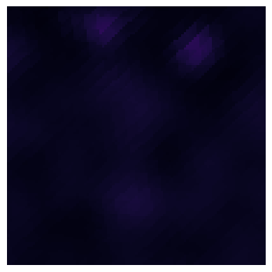

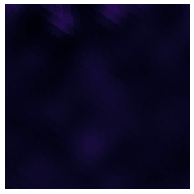

## Sample=5tfq-a:201:cd-a:201:cg-a:201:ce

| pdb_code | central atom | ca density | parallel atom | pa density | planar atom | pl density |
| --- | --- | --- | --- | --- | --- | --- |
| 5tfq | [8.85, 20.05, -3.61] | 186.499 | [8.42, 18.96, -2.66] | 191.4911 | [8.89, 19.63, -5.05] | 176.8439 |

## Slices along x,y and z

Sliced x-wise

Sliced y-wise

Sliced z-wise

50/101

50/101

50/101

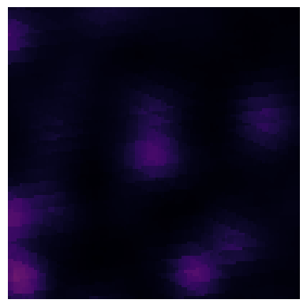

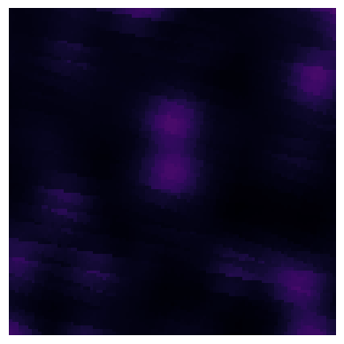

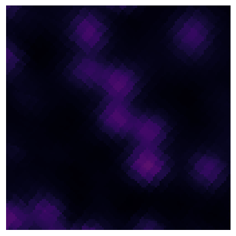

## Sample=2h5p-a:184:cd-a:184:cg-a:184:ce

| pdb_code | central atom | ca density | parallel atom | pa density | planar atom | pl density |
| --- | --- | --- | --- | --- | --- | --- |
| 2h5p | [55.43, 13.28, 21.36] | 89.4468 | [55.03, 13.77, 22.75] | 97.1885 | [54.3, 12.81, 20.47] | 77.6276 |

## Slices along x,y and z

Sliced x-wise

Sliced y-wise

Sliced z-wise

50/101

50/101

50/101

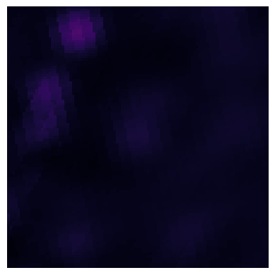

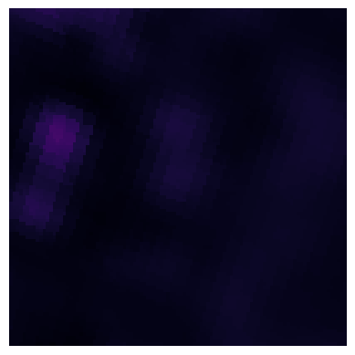

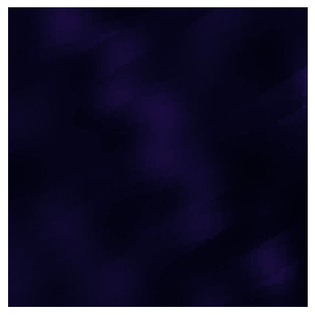

## Sample=6sao-a:102:cd-a:102:cg-a:102:ce

| pdb_code | central atom | ca density | parallel atom | pa density | planar atom | pl density |
| --- | --- | --- | --- | --- | --- | --- |
| 6sao | [-34.01, 10.72, 21.09] | 66.458 | [-33.27, 12.03, 20.76] | 96.9162 | [-34.75, 10.66, 22.41] | 60.7928 |

## Slices along x,y and z

Sliced x-wise

Sliced y-wise

Sliced z-wise

50/101

50/101

50/101

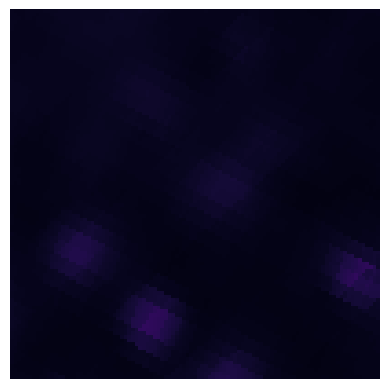

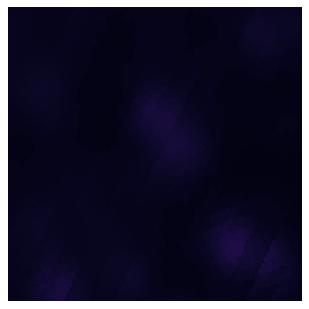

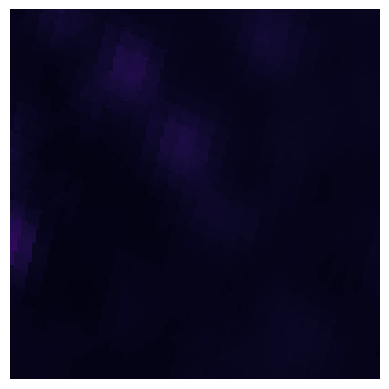

## Sample=6evg-a:278:cd-a:278:cg-a:278:ce

| pdb_code | central atom | ca density | parallel atom | pa density | planar atom | pl density |
| --- | --- | --- | --- | --- | --- | --- |
| 6evg | [-12.79, 0.52, -6.55] | 68.1695 | [-13.02, 0.67, -5.05] | 109.1491 | [-12.74, 1.88, -7.26] | 65.2426 |

## Slices along x,y and z

Sliced x-wise

Sliced y-wise

Sliced z-wise

50/101

50/101

50/101

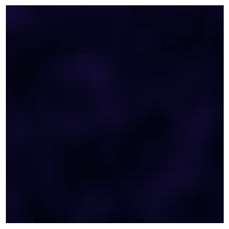

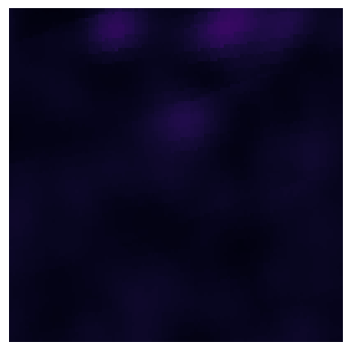

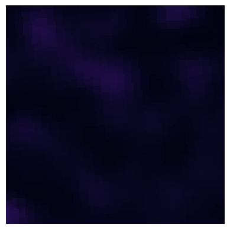

## Sample=3u7c-a:252:cd-a:252:cg-a:252:ce

| pdb_code | central atom | ca density | parallel atom | pa density | planar atom | pl density |
| --- | --- | --- | --- | --- | --- | --- |
| 3u7c | [3.16, -1.79, 32.71] | 90.8228 | [2.18, -2.69, 33.41] | 105.0163 | [4.32, -2.51, 32.08] | 81.6218 |

## Slices along x,y and z

Sliced x-wise

Sliced y-wise

Sliced z-wise

50/101

50/101

50/101

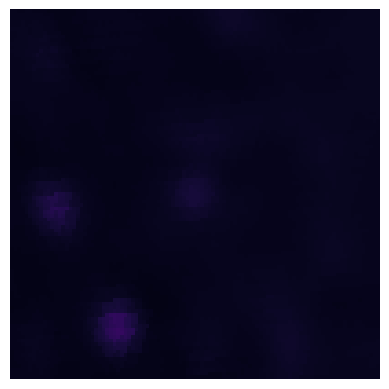

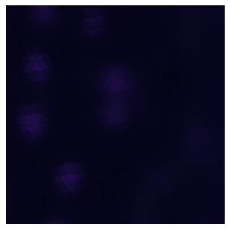

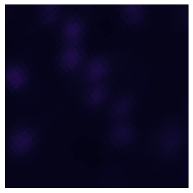

## Sample=3x00-a:121:cd-a:121:cg-a:121:ce

| pdb_code | central atom | ca density | parallel atom | pa density | planar atom | pl density |
| --- | --- | --- | --- | --- | --- | --- |
| 3x00 | [25.98, -60.02, 5.45] | 98.2174 | [26.95, -60.27, 6.62] | 95.01 | [26.8, -59.38, 4.39] | 80.2937 |

## Slices along x,y and z

Sliced x-wise

Sliced y-wise

Sliced z-wise

50/101

50/101

50/101

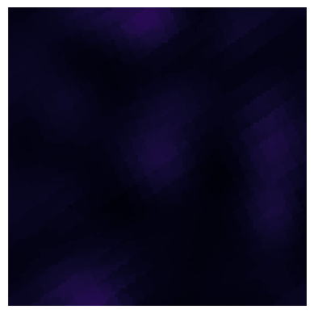

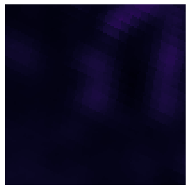

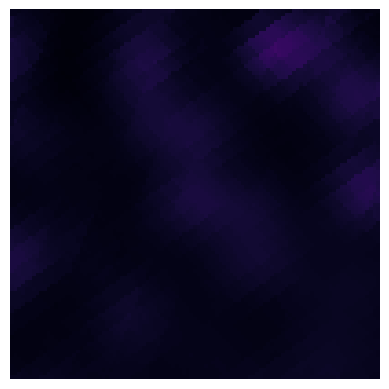

## Sample=6hqc-a:109:cd-a:109:cg-a:109:ce

| pdb_code | central atom | ca density | parallel atom | pa density | planar atom | pl density |
| --- | --- | --- | --- | --- | --- | --- |
| 6hqc | [18.96, -18.51, 0.41] | 56.4636 | [18.46, -17.43, -0.54] | 79.0633 | [20.06, -18.0, 1.32] | 45.4522 |

## Slices along x,y and z

Sliced x-wise

Sliced y-wise

Sliced z-wise

50/101

50/101

50/101

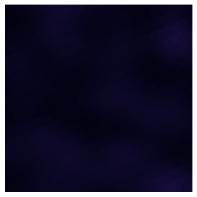

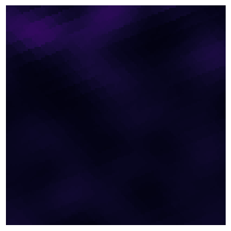

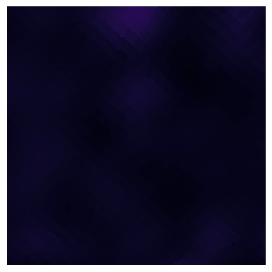

## Sample=6n36-a:86:cd-a:86:cg-a:86:ce

| pdb_code | central atom | ca density | parallel atom | pa density | planar atom | pl density |
| --- | --- | --- | --- | --- | --- | --- |
| 6n36 | [22.93, -9.68, 24.77] | 89.9914 | [22.49, -8.4, 25.48] | 106.0613 | [22.85, -10.89, 25.69] | 75.2555 |

## Slices along x,y and z

Sliced x-wise

Sliced y-wise

Sliced z-wise

50/101

50/101

50/101

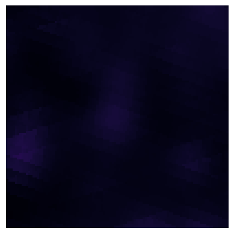

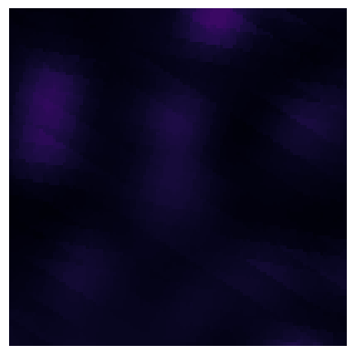

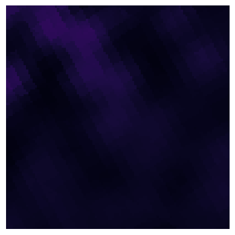

## Sample=3bvx-a:654:cd-a:654:cg-a:654:ce

| pdb_code | central atom | ca density | parallel atom | pa density | planar atom | pl density |
| --- | --- | --- | --- | --- | --- | --- |
| 3bvx | [23.12, 92.83, -35.5] | 58.3062 | [24.52, 93.21, -35.86] | 65.4764 | [22.43, 91.93, -36.52] | 58.779 |

## Slices along x,y and z

Sliced x-wise

Sliced y-wise

Sliced z-wise

50/101

50/101

50/101

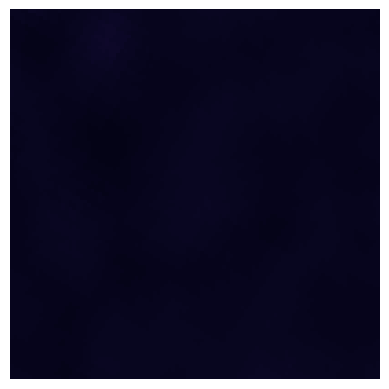

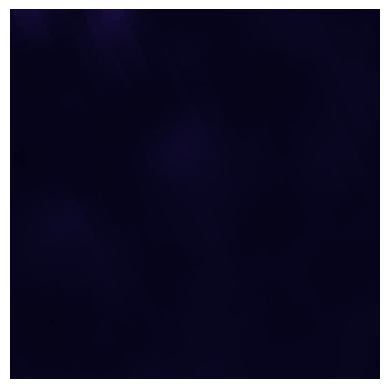

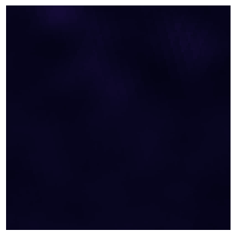

## Sample=5gsm-a:123:cd-a:123:cg-a:123:ce

| pdb_code | central atom | ca density | parallel atom | pa density | planar atom | pl density |
| --- | --- | --- | --- | --- | --- | --- |
| 5gsm | [38.91, 40.2, 105.67] | 91.6677 | [40.4, 39.65, 105.74] | 102.5859 | [38.17, 40.23, 104.38] | 65.2791 |

## Slices along x,y and z

Sliced x-wise

Sliced y-wise

Sliced z-wise

50/101

50/101

50/101

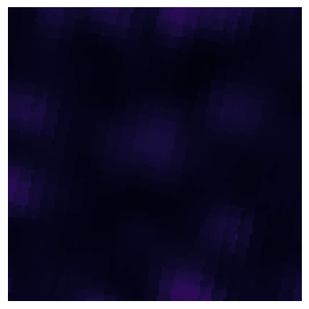

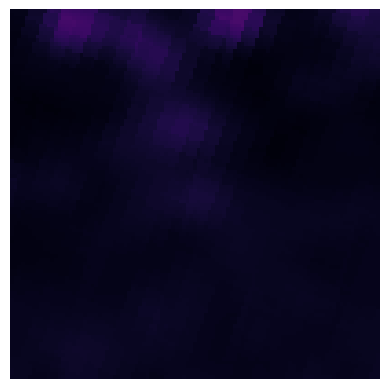

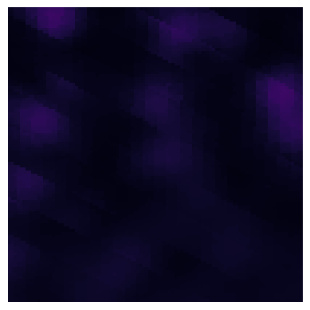

## Sample=3ned-a:184:cd-a:184:cg-a:184:ce

| pdb_code | central atom | ca density | parallel atom | pa density | planar atom | pl density |
| --- | --- | --- | --- | --- | --- | --- |
| 3ned | [-31.38, -8.71, -21.33] | 128.8015 | [-30.96, -8.21, -22.68] | 131.3259 | [-30.18, -9.34, -20.59] | 129.8541 |

## Slices along x,y and z

Sliced x-wise

Sliced y-wise

Sliced z-wise

50/101

50/101

50/101

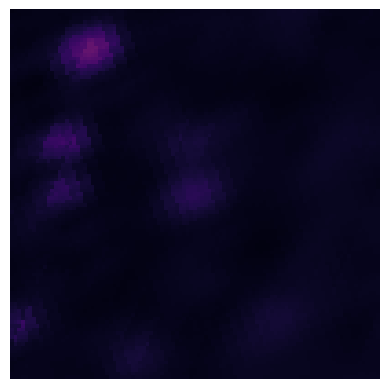

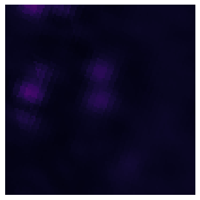

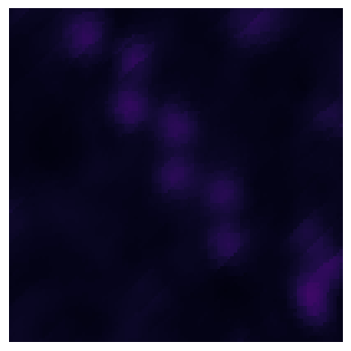